# Ensembling

### What is ensembling?

- Model ensembling is using a combination of models in order to increase performance beyond any of the individual models
- An ensemble is an type of supervised algorithm where we give a weight to the output of each model under consideration. In practice, we tune the weights in order to maximize performance on a validation set. We also set a restriction on the weights making them sum to one.

### Why use ensembling?

- Different types of models have different strengths and weakness
- Some models are better at seperating certain types of noise from signal
- Some models are better at avoiding overfitting/underfitting to certain types of data
- Having multiple models will likely reduce the variance in our predictions, reducing overfitting.

### Example of ensembling two models with the Boston housing data set

- Ensemble of a support vector machine and a random forest model

```python
import numpy as np
import pandas as pd
import matplotlib.pyplot as plt
from sklearn.datasets import load_boston
from sklearn.svm import SVR
from sklearn.ensemble import RandomForestRegressor
from sklearn.metrics import mean_squared_error
%matplotlib inline
```

### Load data and split into training, validation, and test sets

```python
np.random.seed(1)

X, y = load_boston(return_X_y=True)

# 50% train, 25% val, 25% test
num_train = int(round(len(X)*0.6, 0))
num_val = int(round(len(X)*0.2, 0))

random_indices = np.random.permutation(len(X))

train_indices = random_indices[:num_train]
val_indices = random_indices[num_train:(num_train+num_val)]
test_indices = random_indices[(num_train+num_val):]

X_train = X[train_indices]
y_train = y[train_indices]
X_val = X[val_indices]
y_val = y[val_indices]
X_test = X[test_indices]
y_test = y[test_indices]

print('X_train shape:', X_train.shape)
print('y_train shape:', y_train.shape)
print('X_val shape:', X_val.shape)
print('y_val shape:', y_val.shape)
print('X_test shape:', X_test.shape)
print('y_test shape:', y_test.shape)
```

```
X_train shape: (304, 13)
y_train shape: (304,)
X_val shape: (101, 13)
y_val shape: (101,)
X_test shape: (101, 13)
y_test shape: (101,)
```

```python
pd.DataFrame(X_train).head()
```

|  | 0 | 1 | 2 | 3 | 4 | 5 | 6 | 7 | 8 | 9 | 10 | 11 | 12 |
| --- | --- | --- | --- | --- | --- | --- | --- | --- | --- | --- | --- | --- | --- |
| 0 | 0.04932 | 33.0 | 2.18 | 0.0 | 0.472 | 6.849 | 70.3 | 3.1827 | 7.0 | 222.0 | 18.4 | 396.90 | 7.53 |
| 1 | 0.02543 | 55.0 | 3.78 | 0.0 | 0.484 | 6.696 | 56.4 | 5.7321 | 5.0 | 370.0 | 17.6 | 396.90 | 7.18 |
| 2 | 0.22927 | 0.0 | 6.91 | 0.0 | 0.448 | 6.030 | 85.5 | 5.6894 | 3.0 | 233.0 | 17.9 | 392.74 | 18.80 |
| 3 | 0.05789 | 12.5 | 6.07 | 0.0 | 0.409 | 5.878 | 21.4 | 6.4980 | 4.0 | 345.0 | 18.9 | 396.21 | 8.10 |
| 4 | 3.67822 | 0.0 | 18.10 | 0.0 | 0.770 | 5.362 | 96.2 | 2.1036 | 24.0 | 666.0 | 20.2 | 380.79 | 10.19 |

### Scale inputs

- based on the mean and standard deviation of training data

```python
X_train = (X_train - X_train.mean(axis=0))/X_train.std(axis=0)
X_val = (X_val - X_train.mean(axis=0))/X_train.std(axis=0)
X_test = (X_test - X_train.mean(axis=0))/X_train.std(axis=0)
```

```python
pd.DataFrame(X_train).head()
```

|  | 0 | 1 | 2 | 3 | 4 | 5 | 6 | 7 | 8 | 9 | 10 | 11 | 12 |
| --- | --- | --- | --- | --- | --- | --- | --- | --- | --- | --- | --- | --- | --- |
| 0 | -0.414926 | 0.988782 | -1.318844 | -0.265372 | -0.733757 | 0.747471 | 0.066200 | -0.267409 | -0.312360 | -1.124586 | -0.072537 | 0.459241 | -0.685655 |
| 1 | -0.417600 | 1.971393 | -1.085768 | -0.265372 | -0.624920 | 0.529175 | -0.430490 | 0.993954 | -0.538448 | -0.252488 | -0.451911 | 0.459241 | -0.734783 |
| 2 | -0.394787 | -0.485135 | -0.629813 | -0.265372 | -0.951432 | -0.421059 | 0.609343 | 0.972827 | -0.764537 | -1.059768 | -0.309645 | 0.416836 | 0.896268 |
| 3 | -0.413967 | 0.073167 | -0.752178 | -0.265372 | -1.305153 | -0.637929 | -1.681147 | 1.372897 | -0.651493 | -0.399802 | 0.164572 | 0.452207 | -0.605646 |
| 4 | -0.008794 | -0.485135 | 1.000262 | -0.265372 | 1.969037 | -1.374146 | 0.991687 | -0.801313 | 1.609396 | 1.491708 | 0.781055 | 0.295026 | -0.312282 |

### Define & train models

```python
svm = SVR(kernel='linear', epsilon=8, C=0.0003)
rf = RandomForestRegressor(n_estimators=64, max_depth=2, max_features=3)

svm.fit(X_train, y_train)
rf.fit(X_train, y_train)

print('done training')
```

```
done training
```

### Evaluate performance

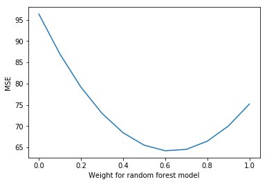

```python
y_vpred_svm = svm.predict(X_val)
y_vpred_rf = rf.predict(X_val)

mse = []
for i in np.arange(0, 1.1, 0.1):
    # start with 100% svm
    ensemble_pred = y_vpred_svm*(1-i) + y_vpred_rf*i
    mse.append(mean_squared_error(y_val, ensemble_pred))

plt.plot(np.arange(0, 1.1, 0.1), mse)
#plt.ylim(0)
plt.xlabel('Weight for random forest model')
plt.ylabel('MSE')
plt.show()
```

#### We can see from the plot above and the table below that the MSE is minimized on the validation set when we give the the random forest model's prediction a weight of 0.6 and the support vector machine's prediction a weight of 0.4

```python
ensemble_scores = pd.DataFrame({
    'RF Weight':np.arange(0, 1.1, 0.1),
    'MSE':mse
})
ensemble_scores
```

|  | MSE | RF Weight |
| --- | --- | --- |
| 0 | 96.374916 | 0.0 |
| 1 | 86.958227 | 0.1 |
| 2 | 79.163296 | 0.2 |
| 3 | 72.990123 | 0.3 |
| 4 | 68.438706 | 0.4 |
| 5 | 65.509048 | 0.5 |
| 6 | 64.201146 | 0.6 |
| 7 | 64.515002 | 0.7 |
| 8 | 66.450615 | 0.8 |
| 9 | 70.007986 | 0.9 |
| 10 | 75.187114 | 1.0 |

### Evaluate on test set

```python
rf_weight = ensemble_scores['RF Weight'].iloc[ensemble_scores['MSE'].idxmin()]

y_pred_svm = svm.predict(X_test)
y_pred_rf = rf.predict(X_test)

y_pred_ensemble = (1-rf_weight)*y_pred_svm + rf_weight*y_pred_rf

print('SVM MSE on test set:', mean_squared_error(y_test, y_pred_svm))
print('RF MSE on test set:', mean_squared_error(y_test, y_pred_rf))
print('Ensemble MSE on test set:', mean_squared_error(y_test, y_pred_ensemble))
```

```
SVM MSE on test set: 95.3476855616
RF MSE on test set: 86.999334848
Ensemble MSE on test set: 70.746944016
```